# Modelling VO2 Data

Shaun Cameron

30/04/2020

# Data Source

The data we will be using for this activity can be found in the **vo2-max_data.xlsx** file and contains data from 100 participants. It has been sourced from an excellent guide for multiple linear regression on www.statistics.laerd.com and consists of the following variables:

**1.** subject_id: unique subject identification number

**2.** age: subject age in years

**3.** weight: subject weight in kilograms

**4.** heart_rate: subject average heart rate in the last 5 minutes of a 20 minute submaximal cycling test

**5.** gender: 1 = male, 0 = female

**6.** vo2_max: VO2max in ml/kg/min recorded from a maximal treadmill test

Each row is one subjects data.

# Our Question

This data has been captured to develop a model to estimate VO2max (response variable) based on a persons age, weight, gender and heart rate during a 20 minute submaximal cycling test (explanatory/predictor variables). This would allow future participants to not have to complete a strenuous maximal running treadmill test (which might deter some participants) and rather, to just complete a less strenuous submaximal test.

We can use multiple linear regression to develop this model.

# Reading in the Data

```r
library(tidyverse) # loads tidyverse package

library(broom) # loads broom package

library(readxl) # loads readxl package
```

```r
dat <- read_excel("data/vo2-max_data.xlsx") # reads in data file, and saves to object dat
```

```r
str(dat) # checks structure of dat
```

```
## Classes 'tbl_df', 'tbl' and 'data.frame':    100 obs. of  6 variables:
##  $ subject_id: num  1 2 3 4 5 6 7 8 9 10 ...
##  $ age       : num  27 63 36 26 24 29 24 27 25 22 ...
##  $ weight    : num  70.5 50.3 87.7 89.8 103 ...
##  $ heart_rate: num  150 144 162 129 143 152 175 160 148 125 ...
##  $ gender    : num  1 0 1 0 1 0 1 0 1 0 ...
##  $ vo2_max   : num  55.8 35 42.9 28.3 40.6 ...
```

```r
head(dat) # shows first 6 rows of dat
```

```
## # A tibble: 6 x 6
##   subject_id   age weight heart_rate gender vo2_max
##        <dbl> <dbl>  <dbl>      <dbl>  <dbl>   <dbl>
## 1          1    27   70.5        150      1    55.8
## 2          2    63   50.3        144      0    35
## 3          3    36   87.6        162      1    42.9
## 4          4    26   89.8        129      0    28.3
## 5          5    24  103.         143      1    40.6
## 6          6    29   77.4        152      0    33
```

```r
tail(dat) # shows last 6 rows of data
```

```
## # A tibble: 6 x 6
##   subject_id   age weight heart_rate gender vo2_max
##        <dbl> <dbl>  <dbl>      <dbl>  <dbl>   <dbl>
## 1         95    38   79.2        155      1    49.4
## 2         96    32  112.         135      1    33.7
## 3         97    33   88.1        130      1    49.2
## 4         98    35   94.1        148      1    42.0
## 5         99    48   97.5        116      1    35.2
## 6        100    51   93.8        124      1    32
```

# Data Transformation

As gender is a categorical vector, its class must be changed from ‘numeric’ to ‘factor’.

```r
dat$gender <- as.factor(dat$gender) # changes gender column in data set from numerical vector
# to factor vector

levels(dat$gender) <- c("female", "male")

str(dat) # shows new structure of dat
```

```
## Classes 'tbl_df', 'tbl' and 'data.frame':    100 obs. of  6 variables:
##  $ subject_id: num  1 2 3 4 5 6 7 8 9 10 ...
##  $ age       : num  27 63 36 26 24 29 24 27 25 22 ...
##  $ weight    : num  70.5 50.3 87.7 89.8 103 ...
##  $ heart_rate: num  150 144 162 129 143 152 175 160 148 125 ...
##  $ gender    : Factor w/ 2 levels "female","male": 2 1 2 1 2 1 2 1 2 1 ...
##  $ vo2_max   : num  55.8 35 42.9 28.3 40.6 ...
```

# Exploratory Data Analysis

## Age vs VO2 Max

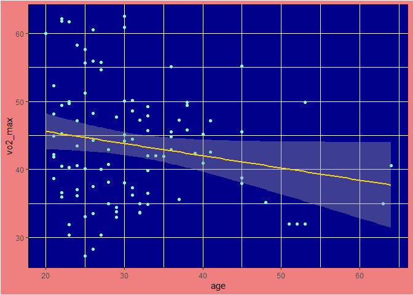

```r
cor(dat$age, dat$vo2_max) # display correlation coefficient of age vs vo2 max
```

```
## [1] -0.1911849
```

## Weight vs VO2 Max

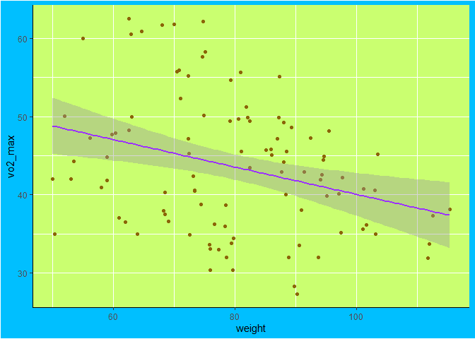

```r
cor(dat$weight, dat$vo2_max) # display correlation coefficient of weight vs vo2 max
```

```
## [1] -0.3074467
```

## Heart Rate vs VO2 Max

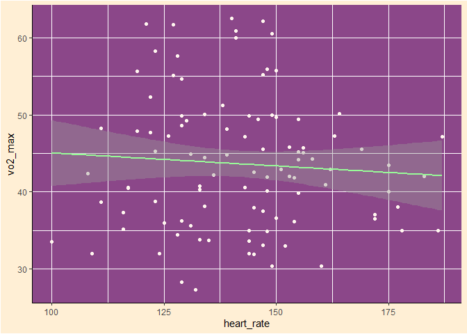

```r
cor(dat$heart_rate, dat$vo2_max) # display correlation coefficient of heart rate vs vo2 max
```

```
## [1] -0.07196356
```

## Gender vs VO2 Max

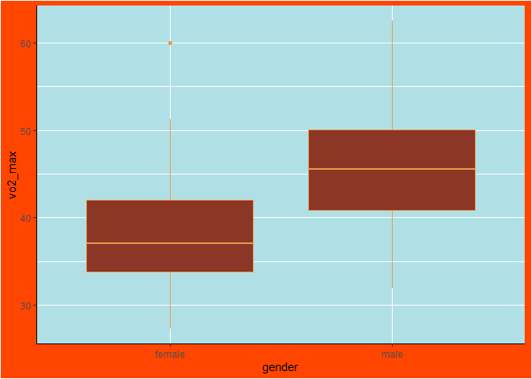

```r
dat %>%
 group_by(gender) %>%
 summarise(mean = mean(vo2_max), median = median(vo2_max), iqr = IQR(vo2_max))
```

```
## # A tibble: 2 x 4
##   gender  mean median   iqr
##   <fct>  <dbl>  <dbl> <dbl>
## 1 female  38.9   37.1  8.16
## 2 male    46.4   45.6  9.22
```

### Comments on Strength & Direction of dat Variables vs VO2 Max

**Age:** weak negative linear relationship

**Weight:** moderate linear relationship

**Heart Rate:** Virtually no linear relationship

**Gender:** Males have higher mean, median and inter quartile range (males less consistent?)

# Accounting for Gender

The following graphs are the same as their above counterparts, separated by gender.

## Age

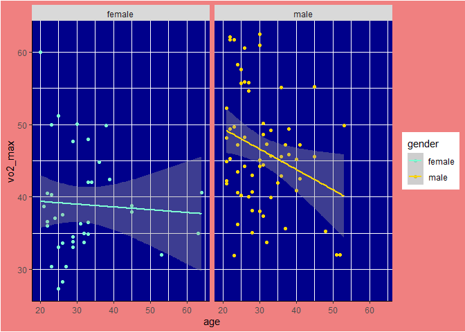

**Male Correlation:**

```
## [1] -0.2857455
```

**Female Correlation:**

```
## [1] -0.05635556
```

## Weight

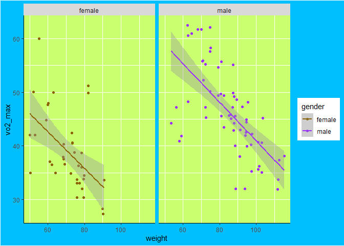

**Male Correlation:**

```
## [1] -0.6542574
```

**Female Correlation:**

```
## [1] -0.5228821
```

## Heart Rate

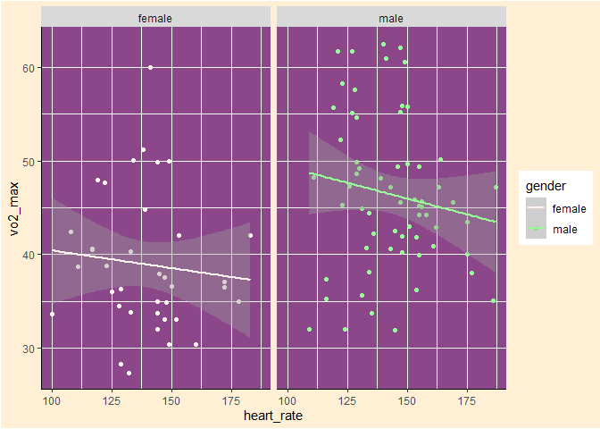

**Male Correlation:**

```
## [1] -0.1486408
```

**Female Correlation:**

```
## [1] -0.09923951
```

### Comments on Strength & Direction of dat Variables vs VO2 Max, Accounting for Gender

**Age:** weak negative linear relationship (male & female)

**Weight:** moderate negative linear (male & female)

**Heart Rate:** weak negative linear relationship (male & female)

## Early Testing for Multicollinearity

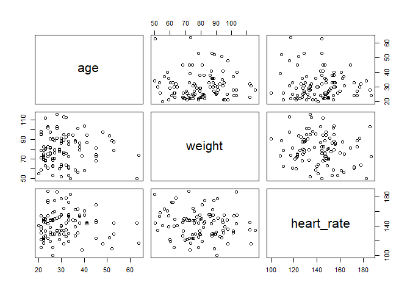

An early look at the data suggests that there is no discernable relationship between the explanatory variables.

# Multiple Linear Regression

## Males

```r
fit_m <- lm(vo2_max ~ age + weight + heart_rate, data = male) # creates linear regression
# model of predicted vo2 max levels against age AND weight AND heart rate,
# when the gender is male

summary(fit_m)
```

```
##
## Call:
## lm(formula = vo2_max ~ age + weight + heart_rate, data = male)
##
## Residuals:
##      Min       1Q   Median       3Q      Max
## -14.7685  -2.6114   0.5523   3.8596  10.6573
##
## Coefficients:
##             Estimate Std. Error t value Pr(>|t|)
## (Intercept) 98.09846    8.06268  12.167  < 2e-16 ***
## age         -0.21171    0.08995  -2.354   0.0219 *
## weight      -0.35579    0.05018  -7.090 1.91e-09 ***
## heart_rate  -0.10451    0.04128  -2.532   0.0140 *
## ---
## Signif. codes:  0 '***' 0.001 '**' 0.01 '*' 0.05 '.' 0.1 ' ' 1
##
## Residual standard error: 5.763 on 59 degrees of freedom
## Multiple R-squared:  0.5197, Adjusted R-squared:  0.4953
## F-statistic: 21.28 on 3 and 59 DF,  p-value: 1.822e-09
```

```r
tidy(fit_m, conf.int = TRUE)
```

```
## # A tibble: 4 x 7
##   term        estimate std.error statistic  p.value conf.low conf.high
##   <chr>          <dbl>     <dbl>     <dbl>    <dbl>    <dbl>     <dbl>
## 1 (Intercept)   98.1      8.06       12.2  1.00e-17   82.0    114.
## 2 age           -0.212    0.0899     -2.35 2.19e- 2   -0.392   -0.0317
## 3 weight        -0.356    0.0502     -7.09 1.91e- 9   -0.456   -0.255
## 4 heart_rate    -0.105    0.0413     -2.53 1.40e- 2   -0.187   -0.0219
```

### Interpretation

When age is increased by 1 year, VO2 Max decreases by 0.212 mL/kg/min, when weight and heart rate do not change.

When weight is increased by 1kg, VO2 max decreases by 0.356 mL/kg/min, when age and heart rate do not change.

When heart rate is increased by 1 bpm, VO2 max decreases by 0.105 mL/kg/min, when age and weight do not change.

This formula can be expressed as **V = -0.212A + -0.356W + -0.105H + 98.099**, where

**V** = VO2 Max

**A** = Age (years)

**W** = Weight (kg)

**H** = Heart Rate (bpm)

**98.099** = y Intercept

## Females

```r
fit_f <- lm(vo2_max ~ age + weight + heart_rate, data = female) # creates linear
# regression model of predicted vo2 max levels against age AND weight AND heart rate,
# when the gender is female

summary(fit_f)
```

```
##
## Call:
## lm(formula = vo2_max ~ age + weight + heart_rate, data = female)
##
## Residuals:
##     Min      1Q  Median      3Q     Max
## -8.5821 -2.8515 -1.6412  0.6971 18.1071
##
## Coefficients:
##              Estimate Std. Error t value Pr(>|t|)
## (Intercept) 100.44754   13.26697   7.571 1.04e-08 ***
## age          -0.14473    0.09091  -1.592  0.12092
## weight       -0.48515    0.09612  -5.047 1.61e-05 ***
## heart_rate   -0.16198    0.05528  -2.930  0.00611 **
## ---
## Signif. codes:  0 '***' 0.001 '**' 0.01 '*' 0.05 '.' 0.1 ' ' 1
##
## Residual standard error: 5.639 on 33 degrees of freedom
## Multiple R-squared:  0.4432, Adjusted R-squared:  0.3926
## F-statistic: 8.757 on 3 and 33 DF,  p-value: 0.0002054
```

```r
tidy(fit_f, conf.int = TRUE)
```

```
## # A tibble: 4 x 7
##   term        estimate std.error statistic      p.value conf.low conf.high
##   <chr>          <dbl>     <dbl>     <dbl>        <dbl>    <dbl>     <dbl>
## 1 (Intercept)  100.      13.3         7.57 0.0000000104   73.5    127.
## 2 age           -0.145    0.0909     -1.59 0.121          -0.330    0.0402
## 3 weight        -0.485    0.0961     -5.05 0.0000161      -0.681   -0.290
## 4 heart_rate    -0.162    0.0553     -2.93 0.00611        -0.274   -0.0495
```

### Interpretation

When age is increased by 1 year, VO2 Max decreases by 0.145 mL/kg/min, when weight and heart rate do not change.

When weight is increased by 1kg, VO2 max decreases by 0.485 mL/kg/min, when age and heart rate do not change.

When heart rate is increased by 1 bpm, VO2 max decreases by 0.162 mL/kg/min, when age and weight do not change.

This formula can be expressed as **V = -0.145A + -0.485W + -0.162H + 100.448**, where

**V** = VO2 Max

**A** = Age (years)

**W** = Weight (kg)

**H** = Heart Rate (bpm)

**100.448** = y Intercept

# Independence of Observations

## Males

```
##  lag Autocorrelation D-W Statistic p-value
##    1     -0.02703478      2.004075   0.976
##  Alternative hypothesis: rho != 0
```

## Females

```
##  lag Autocorrelation D-W Statistic p-value
##    1     -0.03271966      1.980224   0.838
##  Alternative hypothesis: rho != 0
```

### Interpretation

The D-W statistic values are very close to 2 (the ideal value), indicating that there is independence of observations.

# Outliers

## Males

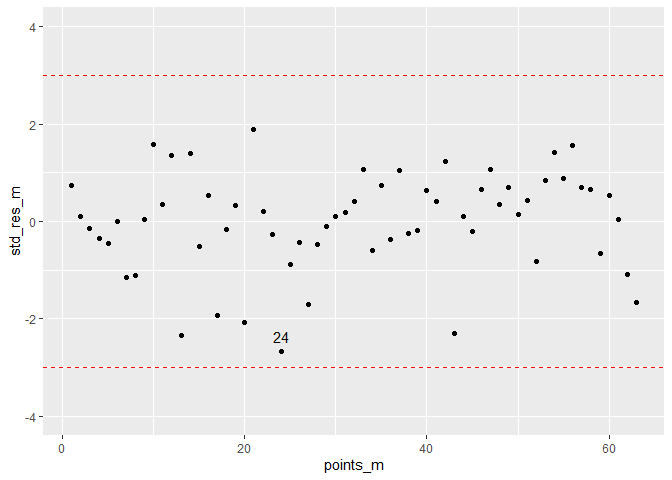

The above plot indicates that all values lie within the limits, although point 24 has been highlighted as a point of interest. Therefore, there are no outliers.

## Females

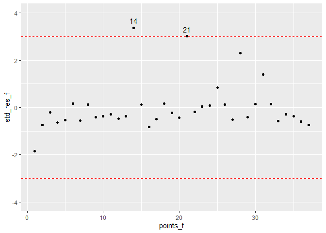

The above plot indicates that the females do have an outlier, and one point of interest. Whether not they have significant leverage or influence will be investigated.

# Leverage Points

## Males

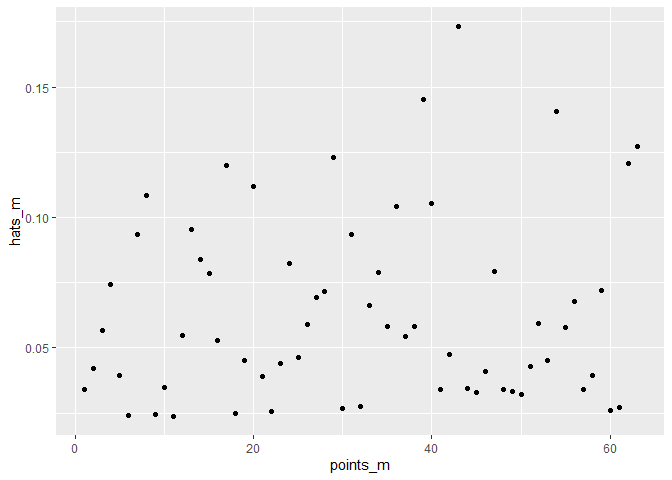

The above plot indicates that there aren’t any points with significant leverage.

## Females

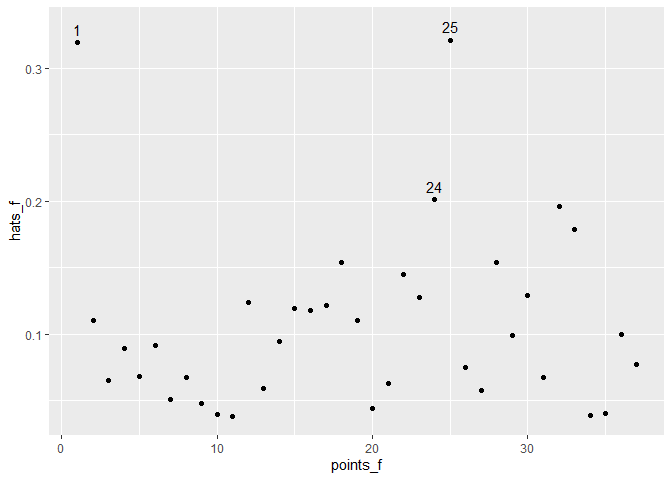

The above plot indicates that there are two points with potential leverage, points 1 and 25. Although 24 is highlighted, I don’t consider it a point with potential for leverage. Interstingly, the point considered an outlier isn’t shown to have much potential for leverage here.

# Influential Points

## Males

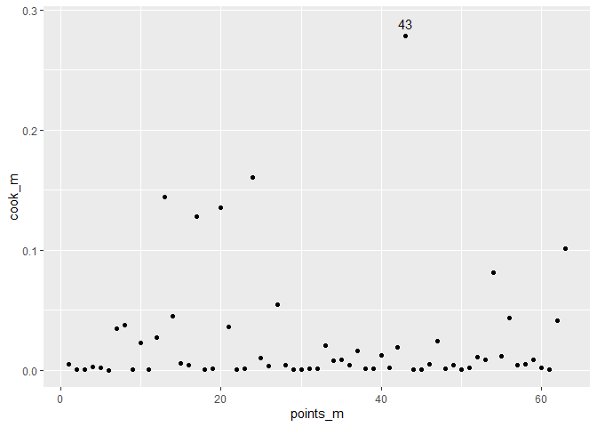

The above graph shows that point 43 has a high chance of influencing the regression fit, so it will be removed from the data and the model will be run again.

## Females

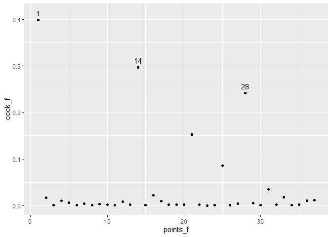

# Re-running the Regression Model Without the Points of Siginificant Influence

## Males

```r
male_new <- male %>%
  filter(subject_id != "73")

fit_m_new <- lm(vo2_max ~ age + weight + heart_rate, data = male_new) # creates linear
# regression model of predicted vo2 max levels against age AND weight AND heart rate,
# when the gender is male

summary(fit_m_new) # generates regression model output
```

```
##
## Call:
## lm(formula = vo2_max ~ age + weight + heart_rate, data = male_new)
##
## Residuals:
##      Min       1Q   Median       3Q      Max
## -14.1598  -2.1869   0.7589   3.5935  11.0930
##
## Coefficients:
##             Estimate Std. Error t value Pr(>|t|)
## (Intercept) 99.83545    7.78998  12.816  < 2e-16 ***
## age         -0.14064    0.09146  -1.538  0.12958
## weight      -0.35970    0.04830  -7.446 5.21e-10 ***
## heart_rate  -0.12793    0.04089  -3.128  0.00275 **
## ---
## Signif. codes:  0 '***' 0.001 '**' 0.01 '*' 0.05 '.' 0.1 ' ' 1
##
## Residual standard error: 5.544 on 58 degrees of freedom
## Multiple R-squared:  0.5393, Adjusted R-squared:  0.5155
## F-statistic: 22.63 on 3 and 58 DF,  p-value: 7.949e-10
```

```r
tidy(fit_m_new, conf.int = TRUE) # generates tidier regression model output
```

```
## # A tibble: 4 x 7
##   term        estimate std.error statistic  p.value conf.low conf.high
##   <chr>          <dbl>     <dbl>     <dbl>    <dbl>    <dbl>     <dbl>
## 1 (Intercept)   99.8      7.79       12.8  1.45e-18   84.2    115.
## 2 age           -0.141    0.0915     -1.54 1.30e- 1   -0.324    0.0424
## 3 weight        -0.360    0.0483     -7.45 5.21e-10   -0.456   -0.263
## 4 heart_rate    -0.128    0.0409     -3.13 2.75e- 3   -0.210   -0.0461
```

Removing the influential data point increased the R squared value by 0.0196, increasing the strength of the correlation, but not by enough to warrant a rethink of the formula.

## Females

```r
female_new <- female %>%
  filter(subject_id != "2",
         subject_id != "28",
         subject_id != "68")

fit_f_new <- lm(vo2_max ~ age + weight + heart_rate, data = female_new) # creates linear
# regression model of predicted vo2 max levels against age AND weight AND heart rate,
# when the gender is female

summary(fit_f_new) # generates regression model output
```

```
##
## Call:
## lm(formula = vo2_max ~ age + weight + heart_rate, data = female_new)
##
## Residuals:
##     Min      1Q  Median      3Q     Max
## -3.4898 -1.3932 -0.9713  0.1764 18.1241
##
## Coefficients:
##              Estimate Std. Error t value Pr(>|t|)
## (Intercept) 103.02599    9.95478  10.349 2.04e-11 ***
## age          -0.05823    0.07404  -0.786    0.438
## weight       -0.53751    0.07434  -7.230 4.77e-08 ***
## heart_rate   -0.17730    0.03916  -4.527 8.82e-05 ***
## ---
## Signif. codes:  0 '***' 0.001 '**' 0.01 '*' 0.05 '.' 0.1 ' ' 1
##
## Residual standard error: 3.903 on 30 degrees of freedom
## Multiple R-squared:  0.6434, Adjusted R-squared:  0.6078
## F-statistic: 18.05 on 3 and 30 DF,  p-value: 6.994e-07
```

```r
tidy(fit_f_new, conf.int = TRUE) # generates tidier regression model output
```

```
## # A tibble: 4 x 7
##   term        estimate std.error statistic  p.value conf.low conf.high
##   <chr>          <dbl>     <dbl>     <dbl>    <dbl>    <dbl>     <dbl>
## 1 (Intercept) 103.        9.95      10.3   2.04e-11   82.7    123.
## 2 age          -0.0582    0.0740    -0.786 4.38e- 1   -0.209    0.0930
## 3 weight       -0.538     0.0743    -7.23  4.77e- 8   -0.689   -0.386
## 4 heart_rate   -0.177     0.0392    -4.53  8.82e- 5   -0.257   -0.0973
```

Removing the influential data points increased the R squared value by 0.2002, dramatically increasing the strength of the correlation. In the case of the female regression equation, predicted values will be taken from this new model, with the new formula being **V = -0.058A + -0.538W + -0.177H + 103.026**.

# Homoscedasticity

## Males

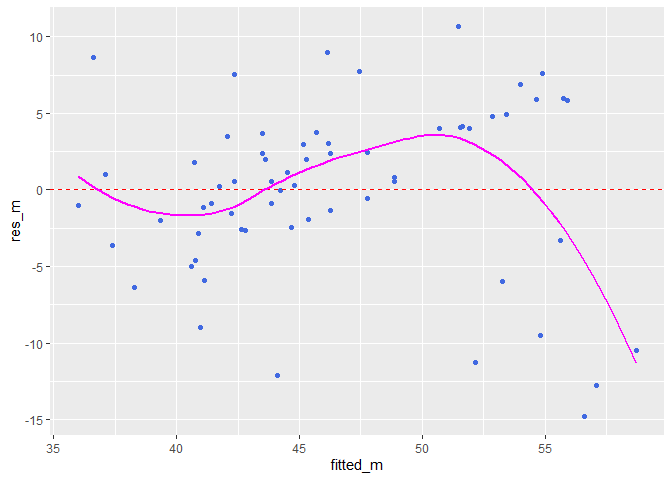

## Females

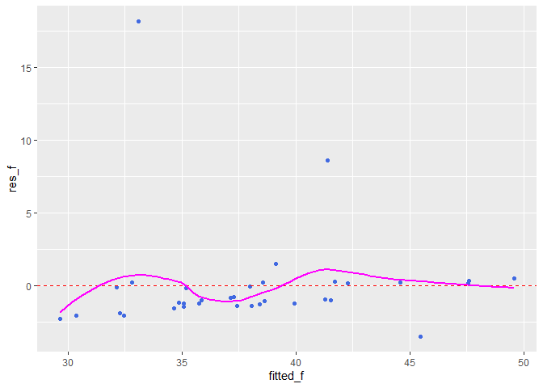

# Normality of Residuals

## Males

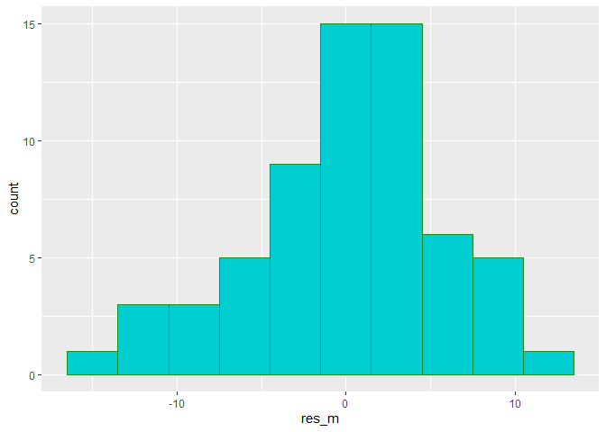

## Females

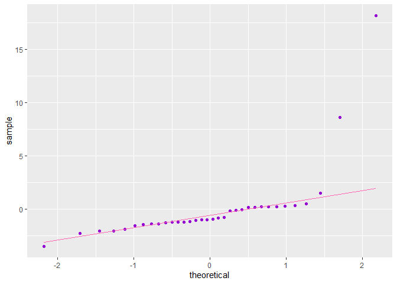

### Interpretation

The male data exhibits normal distribution. For the most part, the female data exhibits normal distribution, apart from one or two data points. Referencing the “res_f” object plotted in the homoscedasticity graph, most of the data points were around 0, which is the case here.

# Multicollinearity

## Males

To test for multicollinearity, I will use the Variation Inflation Factor (VIF). The square root of the VIF indicates how much larger the standard error increases compared to if that that variable had 0 correlation to other predictors.

```
##        age     weight heart_rate
##   1.011220   1.013650   1.007021
```

## Females

```
##        age     weight heart_rate
##   1.018173   1.145569   1.139708
```

The recommended cut off point of the VIF is around 5. With the values of both the male female datasets being close to 1 it can be assumed that there is very little relationship between each explanatory variable, demonstrating a lack of multicollinearity, a positive sign.

# Linearity

To test for linearity, a partial regression model can be used. It plots each x variable against the response while taking into account trhe effect of the other x variables on the response.

## Males

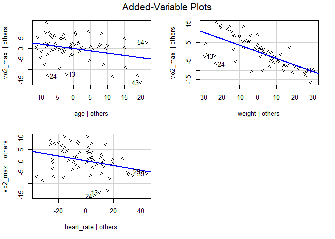

The appearance of a linear relationship in each graph confirms the presence of linearity, which meets one of the key assumptions.

## Females

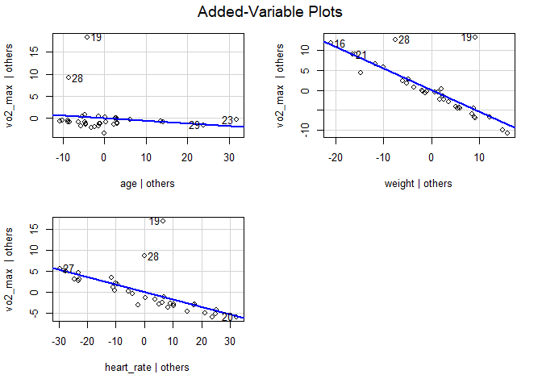

The same applies here for the female data.

# Interpretation

The goal of this analysis was to develop an equation to estimate VO2 Max, using known values along with coefficients from the model created from the data.

This has resulted in two equations being generated:

**V = -0.212A + -0.356W + -0.105H + 98.099** for males, and

**V = -0.058A + -0.538W + -0.177H + 103.026** for females, where

**V** = VO2 Max

**A** = Age (years)

**W** = Weight (kg)

**H** = Heart Rate (bpm)

In an example which puts this equation to work, what is the estimated VO2 max for a person that is 31 years old, female, weighs 68 kgs and has an average heart rate of 140bpm in the last quarter of a submaximal cycling test?

```r
-0.058*31 + -0.538*68 + -0.177*140 + 103.026
```

```
## [1] 39.864
```

The result is that she is likely to have a VO2 max of 39.864 mL/kg/min.

What about a male example?

Theoretical VO2 Max of a 24 year old male who weighs 74kg and has an average heart rate of 160bpm:

```r
-0.212*24 + -0.356*74 + -0.105*160 + 98.099
```

```
## [1] 49.867
```

He is likely to have a VO2 max of 49.867 mL/kg/min.

The main limitation in this model is that the sample size was fairly small (63 males and 37 females), so it may not entirely accurately reflect real values. That being said, there’s enough evidence to believe that the female equation is pretty accurate, given that the R-squared value is above the recommended threshold for meaningful data in biological disciplines. The same is true for the male equation but I feel that a larger sample size will provide a more accurate representation of the data, and therefore increase the reliability of this model.

Another limitation is that the VO2 max measurement is taken from a completely different activity (running instead of cycling). It is also possible that other factors can contribute to VO2 max, like lung capacity, medical conditions, perhaps even height. Further investigation is needed, that’s for sure.